# Developing Data Products Week 4 Project

10 June, 2021

## Introduction

This document is part of the Week 4 assignment for the course of Developing Data Products jointly organized by Coursera and Johns Hopkins University. The project is to develop an App which is an online calculator for Body Mass Index (BMI) - a measure of body fat based on height & weight of adult men and women. It consists of two parts:

1. Create a Shiny application and deploy it on Rstudio’s servers - Shiny website https://kenyang.shinyapps.io/bmi_calculator/
2. Use Rstudio Presenter to prepare a reproducible pitch presentation about the application. The presentation is available in RPub https://rpubs.com/kenyang/780152

All files are stored at Github Repository: https://github.com/kenyang88/DevelopingDataProducts-Week4Project

## Application Overview

- The application is written in Shiny which is a web application framework for R
- The source code consists of two files: server.R and ui.R
- server.R includes the the server logic of a Shiny web application
- ui.R includes the the user-interface definition, which uses the sidebarLayout template
- The coding for server.R and ui.R code are shared on github
- The application is hosted on cloud supported by Rstudio’s shiny server (Shinyapps.io)

## Application Panels and Widgets of BMI Calculator

- SIDE PANEL: provide Input parameters for weight, height and type of measurement.
- MAIN PANEL: contain two tabs displaying (1) calculated BMI & (2) BMI Chart - that user could refer to see if body weight is appropriate with respect to body height.
- widget of selectInput for measurement: A box with 2 choices to select either “kg vs cm” or “lb vs inches”
- widget of numericInput for weight: A field to enter weight
- widget of numericInput for height: A field to enter height
- widget of actionButton for calculation: An Action Button to calculate

## How can we use the BMI Calculator App?

1. Select the measurement type.
2. Enter your body weight and height.
3. Click the CALCULATE button.

Once the CALCULATE button is clicked, the BMI will be displayed on the Main Panel. The BMI Chart tab can be used for reference to see the status whether you are normal, overweight or underweight.

## User Interface of BMI Calculator App

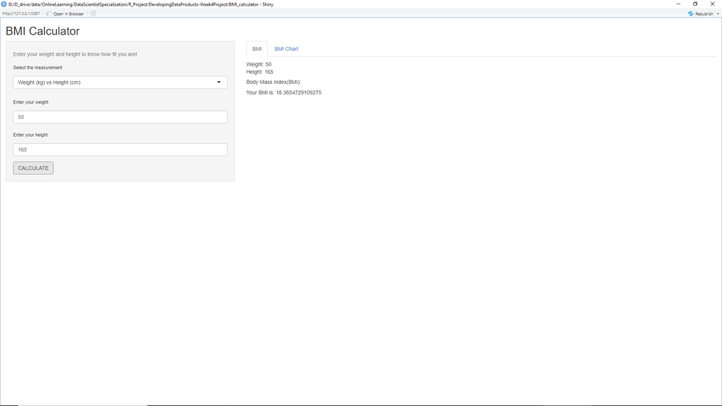